# Week 4 Natural Language Processing

## Step 1 Description of the the problem and Data

The data comes from a Kaggle competition. This came directly from their competition website https://www.kaggle.com/competitions/nlp-getting-started/overview

Competition Description Twitter has become an important communication channel in times of emergency.

The ubiquitousness of smartphones enables people to announce an emergency they’re observing in real-time. Because of this, more agencies are interested in programatically monitoring Twitter (i.e. disaster relief organizations and news agencies).

In this competition, you’re challenged to build a machine learning model that predicts which Tweets are about real disasters and which one’s aren’t. You’ll have access to a dataset of 10,000 tweets that were hand classified. If this is your first time working on an NLP problem, we've created a quick tutorial to get you up and running.

Disclaimer: The dataset for this competition contains text that may be considered profane, vulgar, or offensive.

The training dataset has an extra column called target which is the designation of if it was a disaster tweet or a non-disaster tweet.

Now we will get started on the project by declaring some of the python libraries as well as downloading a list of stop words typically used.

```python
import pandas as pd
import numpy as np
import os
import re
import string
import seaborn as sns
import matplotlib.pyplot as plt
from wordcloud import WordCloud
from collections import Counter
from sklearn.feature_extraction.text import CountVectorizer

from sklearn.model_selection import train_test_split
from sklearn.feature_extraction.text import TfidfVectorizer
from sklearn.linear_model import LogisticRegression
from sklearn.metrics import classification_report
from nltk.corpus import stopwords
import nltk

# Optional: download stopwords for nltk (run once)
nltk.download('stopwords')
from nltk.corpus import stopwords

# Path to your local dataset
data_path = r"C:\Users\dvanbooven\Downloads\nlp-getting-started\train.csv"

# Load training data
df = pd.read_csv(data_path)
```

```python
df.head()
```

|  | id | keyword | location | text | target |
| --- | --- | --- | --- | --- | --- |
| 0 | 1 | NaN | NaN | Our Deeds are the Reason of this #earthquake M... | 1 |
| 1 | 4 | NaN | NaN | Forest fire near La Ronge Sask. Canada | 1 |
| 2 | 5 | NaN | NaN | All residents asked to 'shelter in place' are ... | 1 |
| 3 | 6 | NaN | NaN | 13,000 people receive #wildfires evacuation or... | 1 |
| 4 | 7 | NaN | NaN | Just got sent this photo from Ruby #Alaska as ... | 1 |

# Step 2 -> Exploratory Data Analysis (EDA) : Inspect, Visualize and Clean the data

### Simple count

This is just a simple histogram of the tweets separated by disaster and non-disaster. It's always a good idea to have as much balance in the data as possible, and you can see here that it's pretty close.

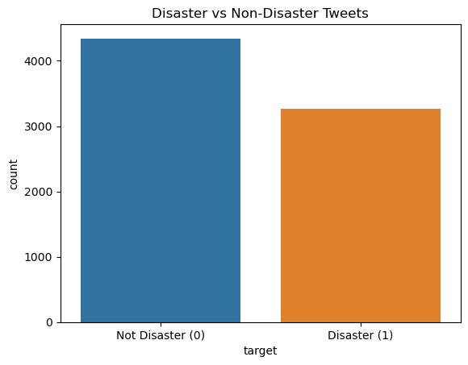

```python
sns.countplot(x='target', data=df)
plt.title('Disaster vs Non-Disaster Tweets')
plt.xticks([0,1], ['Not Disaster (0)', 'Disaster (1)'])
plt.show()
```

### Tweet Length Distribution

Here we want to see the freuqency distribution of the length of the tweets.

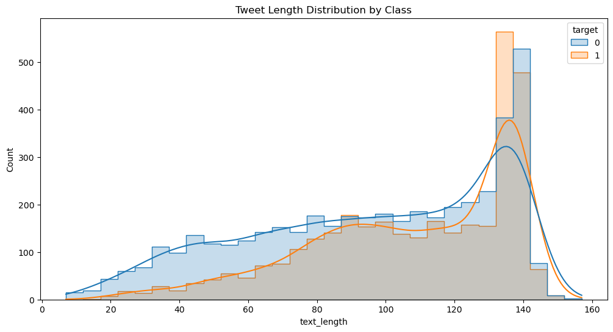

```python
df['text_length'] = df['text'].apply(len)
plt.figure(figsize=(12,6))
sns.histplot(data=df, x='text_length', hue='target', bins=30, kde=True, element='step')
plt.title('Tweet Length Distribution by Class')
plt.show()
```

### Word Frequency

It's vitally important to look at the distribution of words used in diaster vs non-disaster tweets.

```
Top 20 words (ALL):
          word  count
0         like    345
1         just    320
2           im    306
3          amp    300
4          new    226
5         dont    208
6         news    198
7       people    196
8        video    165
9    emergency    157
10    disaster    153
11      police    141
12        time    127
```

[output cut: 53 more lines]

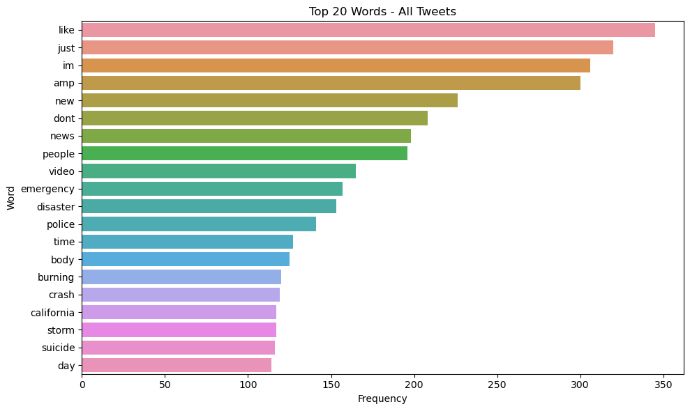

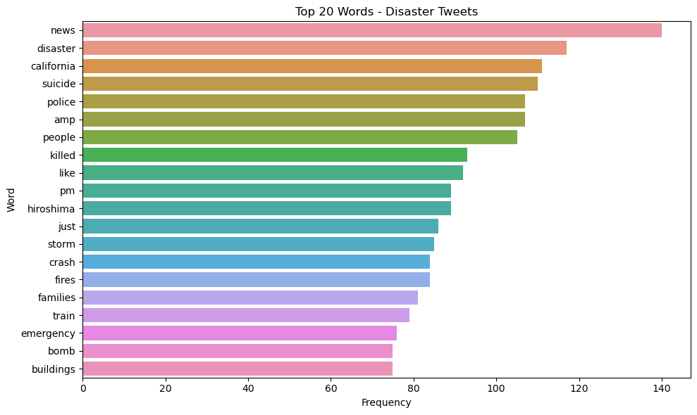

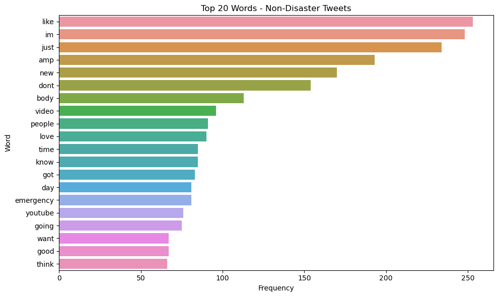

```python
def clean_text(text):
    text = text.lower()
    text = re.sub(r"http\S+", "", text)  # remove links
    text = re.sub(r"[^a-zA-Z\s]", "", text)
    return text

df['text_clean'] = df['text'].apply(clean_text)

stop_words = set(stopwords.words('english'))

def get_top_n_words(corpus, n=None):
    vec = CountVectorizer(stop_words='english').fit(corpus)
    bag_of_words = vec.transform(corpus)
    sum_words = bag_of_words.sum(axis=0)
    words_freq = [(word, sum_words[0, idx]) for word, idx in vec.vocabulary_.items()]
    words_freq = sorted(words_freq, key = lambda x: x[1], reverse=True)
    return pd.DataFrame(words_freq[:n], columns=['word', 'count'])


print("Top 20 words (ALL):")
print(get_top_n_words(df['text_clean'], 20))

print("\nTop 20 words (DISASTER):")
print(get_top_n_words(df[df.target == 1]['text_clean'], 20))

print("\nTop 20 words (NON-DISASTER):")
print(get_top_n_words(df[df.target == 0]['text_clean'], 20))

def plot_top_words(df_words, title):
    plt.figure(figsize=(10,6))
    sns.barplot(y='word', x='count', data=df_words)
    plt.title(title)
    plt.xlabel("Frequency")
    plt.ylabel("Word")
    plt.tight_layout()
    plt.show()

# Top 20 words overall
top_words_all = get_top_n_words(df['text_clean'], 20)
top_words_disaster = get_top_n_words(df[df.target==1]['text_clean'], 20)
top_words_nondisaster = get_top_n_words(df[df.target==0]['text_clean'], 20)

plot_top_words(top_words_all, "Top 20 Words - All Tweets")
plot_top_words(top_words_disaster, "Top 20 Words - Disaster Tweets")
plot_top_words(top_words_nondisaster, "Top 20 Words - Non-Disaster Tweets")
```